# FSD Lab Programs

#### 1. Create the below registration form using forms in HTML

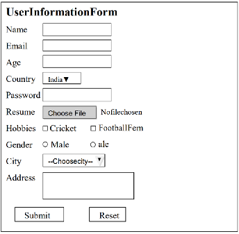

```python
<!-- index.html -->
<!DOCTYPE html>
<html>
<head>
  <title>User Information</title>
  <link rel="stylesheet" href="style.css">
</head>
<body>

<h3>User Information Form</h3>

<form>

<label for="name">Name</label>
<input type="text" id="name" name="name"><br><br>

<label>Email</label>
<input type="email"><br><br>

<label>Age</label>
<input type="number"><br><br>

<label for="country">Country</label>
<select id="country" name="country">
  <option value="india">India</option>
  <option value="usa">USA</option>
  <option value="uk">UK</option>
</select><br><br>

<label>Password</label>
<input type="password"><br><br>

<label>Resume</label>
<input type="file" accept=".pdf,.doc,.docx"><br><br>

<label for="hobbies">Hobbies:</label>

<input type="checkbox" id="cricket" name="hobbies" value="cricket"> Cricket

<input type="checkbox" id="football" name="hobbies" value="football"> Football


<label>Gender</label>
<input type="radio" name="g" value="m"> Male
<input type="radio" name="g" value="f"> Female<br><br>

<label>City</label>
<select>
  <option>--Choose city--</option>
  <option>Mysore</option>
  <option>Bangalore</option>
</select><br><br>

<label>Address</label><br>
<textarea rows="3"></textarea><br><br>

<input type="submit">
<input type="reset">

</form>

</body>
</html>
```

#### 2. Design a webpage using HTML that meets the following requirements:

1. Create a table as shown below.
2. The first row of the table should include the headers: "Column 1", "Column 2"and "Column 3".
3. Add two additional rows with sample data under these headers.
4. Use inline CSS to: a. Add a border to the table and its cells. b. Center-align all the text within the table.

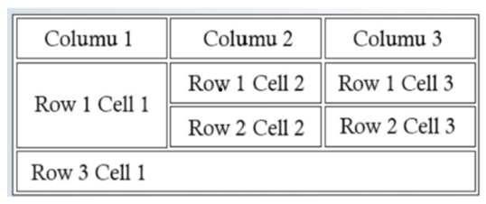

```python
<!DOCTYPE html>
<html>
<body>

<table style="border:1px solid #000;text-align:center;">
  <tr>
    <th style="border:1px solid #000;">Column 1</th>
    <th style="border:1px solid #000;">Column 2</th>
    <th style="border:1px solid #000;">Column 3</th>
  </tr>

  <tr>
    <td style="border:1px solid #000;" rowspan="2">Row 1 Cell 1</td>
    <td style="border:1px solid #000;">Row 1 Cell 2</td>
    <td style="border:1px solid #000;">Row 1 Cell 3</td>
  </tr>

  <tr>
    <td style="border:1px solid #000;">Row 2 Cell 2</td>
    <td style="border:1px solid #000;">Row 2 Cell 3</td>
  </tr>

  <tr>
    <td style="border:1px solid #000;" colspan="3">Row 3 Cell 1</td>
  </tr>
</table>

</body>
</html>
```

#### 3. Create a visually appealing webpage that showcases the CSS box model by applying styling to a <div> element, incorporating padding, margins and borders. Additionally, include an image and a hyperlink within the page to enhance the layout.

```python
<!DOCTYPE html>
<html>
<head>
  <title>CSS Box Model</title>
  <style>
    body { font-family: Arial; background:#f2f2f2; text-align:center; }
    .box {
      width: 300px;
      margin: 40px auto;
      padding: 20px;
      border: 5px solid #4f46e5;
      background: white;
      border-radius: 10px;
    }
  </style>
</head>
<body>

  <h2>CSS Box Model Demo</h2>

  <div class="box">
    <img src="https://images.unsplash.com/photo-1500530855697-b586d89ba3ee" alt="nature" width="100" height="100">
    <p>This box shows <b>margin + border + padding + content</b>.</p>
    <a href="https://example.com">Learn more →</a>
  </div>

</body>
</html>
```

#### 4. Write a JavaScript program that demonstrates how to handle events from different HTML elements. The program should:

1. Trigger an alert when the user clicks anywhere on the body of the page.
2. Change the text of a button when it is clicked and display a success message below the button.
3. Dynamically update a paragraph with the text entered in a text box as the user types.
4. Display a password strength message (weak, medium, or strong) based on the length of the entered password, updating the message as the user types.
5. Ensure that the program uses appropriate event handlers for each element and explains the purpose of each event handler in the program.

```python
<!DOCTYPE html>
<html>
<head>
  <title>Event Handling Demo</title>
  <style>
    .success { color: green; }
  </style>
</head>

<body onclick="bodyClicked()">
  <h2>JavaScript Event Handling Demo</h2>

  <!-- Button click event -->
  <button id="btn" onclick="changeText()">Click Me</button>
  <p id="msg" class="success"></p>

  <!-- Textbox input event -->
  <input type="text" id="nameInput" placeholder="Type something..." oninput="updateText()" />
  <p id="liveText"></p>

  <!-- Password input event -->
  <input type="password" id="pass" placeholder="Enter password" oninput="checkStrength()" />
  <p id="strength"></p>

<script>
  // 1. Body click event → shows alert
  function bodyClicked() {
    alert("You clicked on the page!");
  }

  // 2. Button click → change text + show success message
  function changeText() {
    const btn = document.getElementById("btn");
    btn.innerText = "Clicked!";
    document.getElementById("msg").innerText = "✅ Button clicked successfully";
  }

  // 3. Update paragraph as user types
  function updateText() {
    const text = document.getElementById("nameInput").value;
    document.getElementById("liveText").innerText = "You typed: " + text;
  }

  // 4. Password strength checker
  function checkStrength() {
    const pass = document.getElementById("pass").value;
    const output = document.getElementById("strength");

    if (pass.length < 4) output.innerText = "Strength: Weak";
    else if (pass.length < 8) output.innerText = "Strength: Medium";
    else output.innerText = "Strength: Strong";
  }
</script>
</body>
</html>
```

#### 5. Create a JavaScript program where a random number between 1 and 100 is generated and the user is prompted to guess the number. Provide feedback on whether the guess is too high, too low, or correct, and allow the user to keep guessing until they get it right. After a correct guess, ask if they want to play again using confirm(); if yes, restart the game, otherwise, display "Thanks for playing!" and end the program.

```python
<!DOCTYPE html>
<html>
<head><title>Number Guessing Game</title></head>
<body>

<script>
do {
  let target = Math.floor(Math.random() * 100) + 1;
  let guess;

  while (guess != target) {
    guess = prompt("Guess a number between 1 and 100:");

    if (guess === null) break; // cancel pressed
    else if (guess < target) alert("Too low!");
    else if (guess > target) alert("Too high!");
    else alert("✅ Correct! You guessed it!");
  }

} while (confirm("Play again?"));

alert("Thanks for playing!");
</script>

</body>
</html>
```

#### 6. Write a JavaScript program to create an array of student objects, convert their marks to CGPA using the map method and display a list of students with a CGPA of 9 or higher. Also, show the total count of students with CGPA 9 and above using the filter and reduce methods.

```python
<!DOCTYPE html>
<html>
<head><title>CGPA Calculator</title></head>
<body>
<h3>Students with CGPA ≥ 9</h3>
<ul id="list"></ul>
<p id="count"></p>

<script>
const students = [
  { name: "Arnav", marks: 95 },
  { name: "Riya", marks: 85 },
  { name: "Kabir", marks: 92 },
  { name: "Meera", marks: 88 },
  { name: "Ananya", marks: 98 }
];

// 1. Convert marks to CGPA using map()
const result = students.map(s => ({
  ...s,
  cgpa: (s.marks / 10).toFixed(1)
}));

// 2. Get students with CGPA ≥ 9 using filter()
const toppers = result.filter(s => s.cgpa >= 9);

// 3. Count them using reduce()
const total = toppers.reduce(count => count + 1, 0);

// Display results
document.getElementById("list").innerHTML =
  toppers.map(s => "<li>" + s.name + " - CGPA: " + s.cgpa + "</li>").join("");

document.getElementById("count").innerText =
  "Total students with CGPA ≥ 9: " + total;
</script>
</body>
</html>
```

#### 7.

#### I. Create an HTML page with a list of items, a few buttons and some paragraphs.

#### II. Write JavaScript to do the following:

a) Change the background color of an element by its id.  
b) Change the text color of all list items (<li>) to blue.  
c) Change the text of all buttons to "Clicked!" when clicked.  
d) Increase the font size of all paragraphs.  
e) Select the first element with a specific class and change its text.

```python
<!DOCTYPE html>
<html>
<head>
  <title>DOM Manipulation</title>
</head>
<body>

<h3 id="box">Color Box</h3>

<ul>
  <li>Apple</li>
  <li>Banana</li>
  <li>Mango</li>
</ul>

<button onclick="changeBtn(this)">Button 1</button>
<button onclick="changeBtn(this)">Button 2</button>

<p>Paragraph one</p>
<p>Paragraph two</p>

<p class="special">Original special text</p>
<p class="special">Another one</p>

<script>
/* a) Change background color by id */
document.getElementById("box").style.background = "lightgreen";

/* b) Change all li text to blue */
document.querySelectorAll("li").forEach(li => {
  li.style.color = "blue";
});

/* c) Change button text when clicked */
function changeBtn(btn){
  btn.innerText = "Clicked!";
}

/* d) Increase all paragraph font size */
document.querySelectorAll("p").forEach(p => {
  p.style.fontSize = "20px";
});

/* e) Change first element with specific class */
document.querySelector(".special").innerText =
  "First special text changed!";
</script>

</body>
</html>
```

#### 8. Demonstrate all the methods of mounting and updating phase of react class Component by changing the city name from “Mysore” to “Bangalore” after 2 seconds and display the same.

```python
import React,{ Component } from "react";
class City extends Component {
    constructor(props) {
        super(props);
        this.state = { city: "Mysore" };
        console.log("Constructor :City initialized");
    }
    static getDerivedStateFromProps(props, state) {
        console.log("getDerivedStateFromProps :Sync state with props if needed");
        return null;
    }
    componentDidMount() {
        console.log("componentDidMount :Component is mounted");
        setTimeout(() => {
            this.setState({ city: "Bangalore" });
        }, 2000);
    }
    shouldComponentUpdate(nextProps, nextState) {
        console.log("shouldComponentUpdate :Component should update");
        return true;
    }
    getSnapshotBeforeUpdate(prevProps, prevState) {
        console.log("getSnapshotBeforeUpdate:Before DOM is updated");
        return null;
    }
    componentDidUpdate(prevProps, prevState, snapshot) {
        console.log("componentDidUpdate:The component is updated");
    }
    render() {
        return (
            <div>
                <h2>Life Cycle Methods</h2>
                <h3>City: {this.state.city}</h3>
            </div>
        );
    }
}
export default City;
```

#### 9. Illustrate react program to implement error boundaries to find

1. Division by zero error.
2. Array index of out of bound.

```python
// ErrorBoundary.js
import React, { Component } from "react";

class ErrorBoundary extends Component {
  constructor(props) {
    super(props);
    this.state = { hasError: false };
  }

  static getDerivedStateFromError(error) {
    return { hasError: true };
  }

  componentDidCatch(error, info) {
    console.log("Error caught:", error, info);
  }

  render() {
    return this.state.hasError
      ? <h3>Error occurred!</h3>
      : this.props.children;
  }
}

export default ErrorBoundary;
```

```python
// Division.js
import React from "react";

function Division() {
  const x = 10, y = 0;
  return <h2>Result: {x / y}</h2>;
}
export default Division;
```

```python
// ArrayError.js
import React from "react";

function ArrayError() {
  const arr = [1, 2, 3];
  return <h2>{arr[5].toString()}</h2>;
}

export default ArrayError;
```

#### 10. Implement a React functional component that:

1. Accepts an age prop and displays it inside a heading (<h1>).
2. Includes an input field and a button that allows the user to update the age in the heading using a state variable (utilizing useState&useEffect).

```python
import { useState, useEffect } from "react";

function Age({ age }) {
  const [newAge, setNewAge] = useState(age);

  useEffect(() => console.log("Age updated:", newAge), [newAge]);

  return (
    <>
      <h1>Age: {newAge}</h1>
      <input id="ageInput" />
      <button onClick={() => setNewAge(document.getElementById("ageInput").value)}>
        Update
      </button>
    </>
  );
}
export default Age;
```

#### 11. Write a react program to create a list of departments and iterate through all the elements of the list and return an unordered list with each department as a list item using a function component.

```python
function Departments() {
  const deps = ["CSE", "ISE", "ECE", "ME", "CIVIL"];
  return (
    <ul>
      {deps.map((d, i) => <li key={i}>{d}</li>)}
    </ul>
  );
}
export default Departments;
```

#### 12. Write a react function component to create a counter that is incremented by one on button click and display a message 'End of the count ' when count reaches 10.

```python
import { useState } from "react";

function Counter() {
  const [c, setC] = useState(0);

  return (
    <>
      <h1>{c}</h1>

      <button onClick={() => c < 10 && setC(c + 1)} disabled={c === 10}>
        Inc
      </button>

      {c === 10 && <p>End of the count</p>}
    </>
  );
}
export default Counter;
```

#### 13. Write a Node.js program to read input from the console and store it in a file using file server module.

```python
const fs = require("fs");

process.stdout.write("Enter text: ");

process.stdin.on("data", d => {
  fs.writeFileSync("output.txt", d.toString()); // write
  console.log("Saved.");
  process.exit(); // exit
});
```

#### 14. Apply the concept of custom modules in Node.js.

1. Create a custom module fileOperations.js with functions to read a file, write to a file and append data to a file.
2. Use this module in another file app.js to demonstrate its functionality by performing file operations.

```python
// fileOperations.js
const fs = require("fs");

exports.writeFile = (f, data) => fs.writeFileSync(f, data);
exports.readFile = f => fs.readFileSync(f, "utf8");
exports.appendFile = (f, data) => fs.appendFileSync(f, data);
```

```python
// App.js
const file = require("./fileOperations");

file.writeFile("a.txt", "Hello");
file.appendFile("a.txt", "\nWorld");
console.log(file.readFile("a.txt"));
```

#### 15. Illustrate how to add an event listener, emit an event to trigger the listener and then remove the event listener in node.js.

```python
const EventEmitter = require("events");
const ev = new EventEmitter();

const hello = () => console.log("Hello event triggered");

ev.on("greet", hello);   // add listener
ev.emit("greet");        // emit event
ev.removeListener("greet", hello); // remove
ev.emit("greet");        // nothing happens
```

#### 16. Explain various debugging and logging methods in Node.js with example to demonstrates the following:

1. Measuring execution time of code blocks.
2. Grouping related log messages and displaying them hierarchically.
3. Using assertions to conditionally display error messages.
4. Displaying data in a tabular format.
5. Logging debugging details for analysis.

```python
console.time("t1");        // measure time
for (let i = 0; i < 1e6; i++) {}
console.timeEnd("t1");

console.group("Logs");     // grouped logs
console.log("Step 1");
console.log("Step 2");
console.groupEnd();

console.assert(5 < 2, "5 is NOT < 2"); // assertion

console.table([{ a: 1, b: 2 }, { a: 3, b: 4 }]); // table

console.debug("Debug info here");  // debugging log
```

#### 17. Write a Node.js program to:

1. Create an HTTP server that listens on port 8000.
2. Respond with “Welcome to Nodejs” when the root URL (/) is accessed.
3. Return a 404 status with a custom message for all other routes.

```python
const http = require("http");

http.createServer((req, res) => {
  if (req.url === "/") {
    res.write("Welcome to Nodejs");
  } else {
    res.statusCode = 404;
    res.write("404 - Route not found");
  }
  res.end();
}).listen(8000, () => console.log("Server running"));
```

#### 18. Demonstrate the following MongoDB operations

1. Write a script to create a new database named CollegeDB and a collection named students.
2. Insert three documents into the students collection with fields name, age, sem, usn and grade.
3. Insert multiple documents into a collection named courses with fields courseName, courseCode, and credits.
4. Write queries to retrieve all documents from the students collection.
5. Retrieve all documents where the age is greater than 18.
6. Write a query to find all students with a grade of "A".
7. Write a query to find all courses with credits greater than or equal to 3.

```python
// create / switch DB
use CollegeDB

// create students collection
db.createCollection("students")

// insert 3 students
db.students.insertMany([
  {name:"Arnav", age:19, sem:3, usn:"1NI23CS01", grade:"A"},
  {name:"Rahul", age:18, sem:2, usn:"1NI23CS02", grade:"B"},
  {name:"Sneha", age:20, sem:4, usn:"1NI23CS03", grade:"A"}
])

// insert courses
db.courses.insertMany([
  {courseName:"DBMS", courseCode:"CS301", credits:4},
  {courseName:"OS", courseCode:"CS302", credits:3},
  {courseName:"AI", courseCode:"CS303", credits:4}
])

// all students
db.students.find()

// age > 18
db.students.find({ age: { $gt: 18 } })

// grade = A
db.students.find({ grade: "A" })

// credits >= 3
db.courses.find({ credits: { $gte: 3 } })
```

#### 19. Demonstrate the following operations using Mongo shell script

1. Switch to the WorkDB database.
2. Create a teachers collection.
3. Insert documents with fields name, subject and experience.
4. Use the Mongo shell to export the students collection to a JSON file.
5. Import the JSON file back into a new collection named studentsBackup.

```python
// switch DB
use WorkDB

// create teachers
db.createCollection("teachers")

// insert teachers
db.teachers.insertMany([
  {name:"Ravi", subject:"Maths", experience:5},
  {name:"Anita", subject:"Physics", experience:8}
])

// terminal (export)
mongoexport --db CollegeDB --collection students --out students.json

// terminal (import)
mongoimport --db WorkDB --collection studentsBackup --file students.json
```

#### 20. Write a MongoDB aggregation query for the following to analyze an employees collection with an example for each:Group the employees by their department and calculate the total number of employees in each department. The average salary of employees in each department.

1. Sort the aggregated results by the total number of employees in descending order.
2. Example Data in the employees Collection.

```python
// sample data
db.employees.insertMany([
  {name:"A", dept:"HR", salary:50000},
  {name:"B", dept:"IT", salary:60000},
  {name:"C", dept:"IT", salary:75000},
  {name:"D", dept:"HR", salary:55000},
  {name:"E", dept:"Sales", salary:40000}
])

// group + avg + count + sort desc
db.employees.aggregate([
  {
    $group: {
      _id: "$dept",
      totalEmployees: { $sum: 1 },
      avgSalary: { $avg: "$salary" }
    }
  },
  { $sort: { totalEmployees: -1 } }
])
```

#### 21. Build a React application using React Router with the following pages:

• Dashboard – shows a list of tasks.  
• Task Details – dynamic route showing task info using /task/:taskId.  
• Settings – contains user preferences. Add a navigation menu and show a “Page Not Found” screen for invalid routes

```python
//index.js
import React from "react";
import ReactDOM from "react-dom/client";
import { BrowserRouter } from "react-router-dom";
import App from "./App";
const root = ReactDOM.createRoot(document.getElementById("root"));
root.render(
  <BrowserRouter>
    <App />
  </BrowserRouter>
);

// If you want to start measuring performance in your app, pass a function
// to log results (for example: reportWebVitals(console.log))
// or send to an analytics endpoint. Learn more: https://bit.ly/CRA-vitals
```

```python
//App.js
import React from "react";
import { Routes, Route, Link } from "react-router-dom";
import Dashboard from "./pages/Dashboard";
import TaskDetails from "./pages/TaskDetails";
import Settings from "./pages/Settings";
import NotFound from "./pages/NotFound";
function App() {
  return (
    <div>
      {/* Simple Navbar */}
      <nav>
        <Link to="/">Dashboard</Link> |{" "}
        <Link to="/settings">Settings</Link>
      </nav>
      {/* Routes */}
      <Routes>
        <Route path="/" element={<Dashboard />} />
        <Route path="/task/:taskId" element={<TaskDetails />} />
        <Route path="/settings" element={<Settings />} />
        <Route path="*" element={<NotFound />} />
      </Routes>
    </div>
  );
}
export default App;
```

```python
//pages/Dashboard.js
import React from "react";
import { Link } from "react-router-dom";

const tasks = [
  { id: 1, title: "Learn React Router" },
  { id: 2, title: "Build a Dashboard" },
  { id: 3, title: "Add Settings Page" }
];
function Dashboard() {
  return (
    <div>
      <h2>Dashboard</h2>
      <ul>
        {tasks.map(task => (
          <li key={task.id}>
            <Link to={"/task/" + task.id}>{task.title}</Link>
          </li>
        ))}
      </ul>
    </div>
  );
}
export default Dashboard;
```

```python
//pages/TaskDetails.js
import React from "react";
import { useParams } from "react-router-dom";
const tasks = {
  1: { title: "Learn React Router", description: "Understand routing basics." },
  2: { title: "Build a Dashboard", description: "Create a task list view." },
  3: { title: "Add Settings Page", description: "Allow user preferences." }
};
function TaskDetails() {
  const { taskId } = useParams();
  const task = tasks[taskId];
  if (!task) return <h2>Task not found</h2>;
  return (
    <div>
      <h2>{task.title}</h2>
      <p>{task.description}</p>
    </div>
  );
}
export default TaskDetails;
```

```python
//pages/Settings.js
import React from "react";
function Settings() {
  return (
    <div>
      <h2>Settings</h2>
      <p>User preferences go here.</p>
    </div>
  );
}
export default Settings;
```

```python
//pages/NotFound.js
import React from "react";
function NotFound() {
  return (
    <div>
      <h2>404 - Page Not Found</h2>
    </div>
  );
}
export default NotFound;
```

#### 22. Design a registration form containing:

1. Username
2. Email
3. Mobile Number
4. Password
5. Confirm Password
6. Branch Selection (dropdown)
7. Upload Profile Picture
8. Register and Reset buttons

Write a JavaScript program that validates:  
i. Username must be at least 6 characters.  
ii. Email must follow correct format.  
iii. Mobile number must contain exactly 10 digits.  
iv. Password must include letters and numbers.  
v. Confirm Password must match.  
vi. Error messages should appear next to each field.  
vii. After successful validation, display the user details in a formatted card using DOM elements.

```python
<!DOCTYPE html>
<html>
<head>
  <title>Registration Form</title>
  <style>
    span{color:red;font-size:12px}
    .card{border:1px solid #000;padding:10px;margin-top:10px;width:250px}
  </style>
</head>
<body>

<h3>Registration Form</h3>

<form onsubmit="return validate()">

Username
<input id="u"><span id="eu"></span><br><br>

Email
<input id="e"><span id="ee"></span><br><br>

Mobile Number
<input id="m"><span id="em"></span><br><br>

Password
<input type="password" id="p"><span id="ep"></span><br><br>

Confirm Password
<input type="password" id="cp"><span id="ecp"></span><br><br>

Branch
<select id="b">
  <option>CSE</option>
  <option>ISE</option>
  <option>ECE</option>
</select><br><br>

Upload Profile Picture
<input type="file"><br><br>

<input type="submit">
<input type="reset">

</form>

<div id="out"></div>

<script>
function validate(){
  let u=document.getElementById("u").value;
  let e=document.getElementById("e").value;
  let m=document.getElementById("m").value;
  let p=document.getElementById("p").value;
  let cp=document.getElementById("cp").value;

  let eu=document.getElementById("eu");
  let ee=document.getElementById("ee");
  let em=document.getElementById("em");
  let ep=document.getElementById("ep");
  let ecp=document.getElementById("ecp");

  eu.innerHTML = u.length<6 ? " minimum 6 characters" : "";
  ee.innerHTML = !/^\S+@\S+\.\S+$/.test(e) ? " invalid email format" : "";
  em.innerHTML = !/^\d{10}$/.test(m) ? " exactly 10 digits" : "";
  ep.innerHTML = !(/[A-Za-z]/.test(p)&&/\d/.test(p)) ? " letters and numbers required" : "";
  ecp.innerHTML = p!==cp ? " passwords do not match" : "";

  if(eu.innerHTML||ee.innerHTML||em.innerHTML||ep.innerHTML||ecp.innerHTML)
    return false;

  out.innerHTML =
  "<div class='card'><b>" + u + "</b><br>" + e + "<br>" + m + "<br>Branch: " + b.value + "</div>";

  return false;
}
</script>

</body>
</html>
```

#### 23. Build a webpage that handles events: onclick, onmouseover, onkeyup, onfocus.

```python
<!DOCTYPE html>
<html>
<head>
  <title>Event Handling Demo</title>
</head>
<body>

<h2>Event Handling Demonstration</h2>

<button onclick="clickEvent()">Click Me</button><br><br>

<div id="box"
     onmouseover="hoverIn()"
     onmouseout="hoverOut()"
     style="width:180px;height:60px;border:1px solid black;text-align:center;">
  Hover Over This Box
</div><br>

Type Something:<br>
<input id="key" onkeyup="keyUp()">
<div id="keyMsg"></div><br>

Focus on this Input:<br>
<input onfocus="focusIn()" onblur="focusOut()">
<div id="focusMsg"></div>

<script>
function clickEvent(){ alert("Button Clicked!"); }

function hoverIn(){ box.style.background="#e0e0e0"; }
function hoverOut(){ box.style.background="white"; }

function keyUp(){ keyMsg.innerHTML="You typed: "+key.value; }

function focusIn(){ focusMsg.innerHTML="Input is focused"; }
function focusOut(){ focusMsg.innerHTML=""; }
</script>

</body>
</html>
```

#### 24. Develop an Express.js API for Teacher Records that performs CRUD operations:

i. Add routes to create, fetch all, fetch by ID, update, and delete teacher details.  
ii. Ensure JSON data is parsed using middleware and invalid requests return error messages.  
iii. Include fields: name, department, experience, and email.  
iv. Return meaningful success messages for each action.

```python
const express = require('express');
const app = express();
app.use(express.json());

let teachers = [
  {id:1,name:"Alice",department:"CSE",experience:5,email:"[email protected]"},
  {id:2,name:"Bob",department:"ECE",experience:8,email:"[email protected]"},
  {id:3,name:"Charlie",department:"ME",experience:4,email:"[email protected]"}
];

let nextId = 4;

const valid = ({name,department,experience,email}) =>
  name && department && experience && email;

// CREATE
app.post('/teachers',(req,res)=>{
  if(!valid(req.body))
    return res.status(400).json({message:"All fields required"});

  const t = { id: nextId++, ...req.body };
  teachers.push(t);
  return res.status(201).json({message:"Teacher created",data:t});
});

// READ ALL
app.get('/teachers',(req,res)=>{
  return res.json({message:"Teachers fetched",data:teachers});
});

// READ BY ID
app.get('/teachers/:id',(req,res)=>{
  const t = teachers.find(x=>x.id==req.params.id);
  if(!t)
    return res.status(404).json({message:"Teacher not found"});

  return res.json({message:"Teacher fetched",data:t});
});

// UPDATE
app.put('/teachers/:id',(req,res)=>{
  const t = teachers.find(x=>x.id==req.params.id);
  if(!t)
    return res.status(404).json({message:"Teacher not found"});

  if(!valid(req.body))
    return res.status(400).json({message:"All fields required"});

  Object.assign(t,req.body);
  return res.json({message:"Teacher updated",data:t});
});

// DELETE
app.delete('/teachers/:id',(req,res)=>{
  const i = teachers.findIndex(x=>x.id==req.params.id);
  if(i === -1)
    return res.status(404).json({message:"Teacher not found"});

  return res.json({
    message:"Teacher deleted",
    data: teachers.splice(i,1)[0]
  });
});

// INVALID ROUTE
app.use((req,res)=>{
  return res.status(404).json({message:"Invalid route"});
});

app.listen(3000,()=>console.log("Server running on port 3000"));
```

#### 25.Create a Course Management API using Node.js and MongoDB:

• Add routes to create, view, update, and delete course details.  
• Each course contains: courseName, faculty, credits, and studentsEnrolled.  
• Implement a separate route /courses/totalStudents to calculate total enrollment across all courses.  
• Use Mongoose validation for required fields.

```python
const express = require('express');
const mongoose = require('mongoose');
const app = express();
app.use(express.json());

// MongoDB connection
mongoose.connect('mongodb://127.0.0.1:27017/CourseDB');

// Schema
const courseSchema = new mongoose.Schema({
  courseName: { type:String, required:true },
  faculty: { type:String, required:true },
  credits: { type:Number, required:true },
  studentsEnrolled: { type:Number, required:true }
});

const Course = mongoose.model('Course', courseSchema);

// CREATE
app.post('/courses', async (req,res)=>{
  try{
    const c = await Course.create(req.body);
    res.status(201).json({message:"Course created",data:c});
  }catch(err){
    res.status(400).json({message:err.message});
  }
});

// READ ALL
app.get('/courses', async (req,res)=>{
  res.json(await Course.find());
});

// READ BY ID
app.get('/courses/:id', async (req,res)=>{
  const c = await Course.findById(req.params.id);
  if(!c) return res.status(404).json({message:"Course not found"});
  res.json(c);
});

// UPDATE
app.put('/courses/:id', async (req,res)=>{
  const c = await Course.findByIdAndUpdate(req.params.id, req.body, {new:true, runValidators:true});
  if(!c) return res.status(404).json({message:"Course not found"});
  res.json({message:"Course updated",data:c});
});

// DELETE
app.delete('/courses/:id', async (req,res)=>{
  const c = await Course.findByIdAndDelete(req.params.id);
  if(!c) return res.status(404).json({message:"Course not found"});
  res.json({message:"Course deleted",data:c});
});

// TOTAL STUDENTS
app.get('/courses/totalStudents', async (req,res)=>{
  const result = await Course.aggregate([
    {$group:{_id:null,total:{$sum:"$studentsEnrolled"}}}
  ]);
  res.json({totalStudents: result[0]?.total || 0});
});

app.listen(3000,()=>console.log("Server running on port 3000"));
```

#### 26.Develop a Node.js program using the MongoDB native driver to accomplish the following:

1. Read a list of employee records from a file named employees.json.
2. Connect to a MongoDB database CompanyDB and insert the records into a collection called employees.
3. Update the record of the employee with empId = 101 by changing the value of the designation field.
4. Retrieve all employee records and write them into a file named updated_employees.json.
5. Display a message confirming that the export process has been successfully completed.

```python
//employeeScript.js
const fs = require("fs");
const { MongoClient } = require("mongodb");

const url = "mongodb://localhost:27017";
const client = new MongoClient(url);

const inputFile = "employees.json";
const outputFile = "updated_employees.json";

// Step 1: Read file
const employees = JSON.parse(fs.readFileSync(inputFile));

async function run() {
  try {
    // Step 2: Connect to DB
    await client.connect();
    const db = client.db("CompanyDB");
    const col = db.collection("employees");

    // Insert records
    await col.insertMany(employees);

    // Step 3: Update empId = 101
    await col.updateOne(
      { empId: 101 },
      { $set: { designation: "Senior Developer" } }
    );

    // Step 4: Fetch all records
    const updated = await col.find().toArray();

    // Write to file
    fs.writeFileSync(outputFile, JSON.stringify(updated, null, 2));

    // Step 5: Success message
    console.log("Employee records exported successfully");

  } catch (err) {
    console.log("Error:", err);
  } finally {
    client.close();
  }
}

run();
```

```python
//employees.json
[
  { "empId": 100, "name": "Arun", "designation": "Developer", "salary": 30000 },
  { "empId": 101, "name": "Priya", "designation": "Tester", "salary": 28000 },
  { "empId": 102, "name": "Rahul", "designation": "Manager", "salary": 45000 }
]
```